# Midterm

Andrea Astudillo

2024-11-04

```r
library(readr)
library(fpp)
library(fpp2)
library(TTR)
```

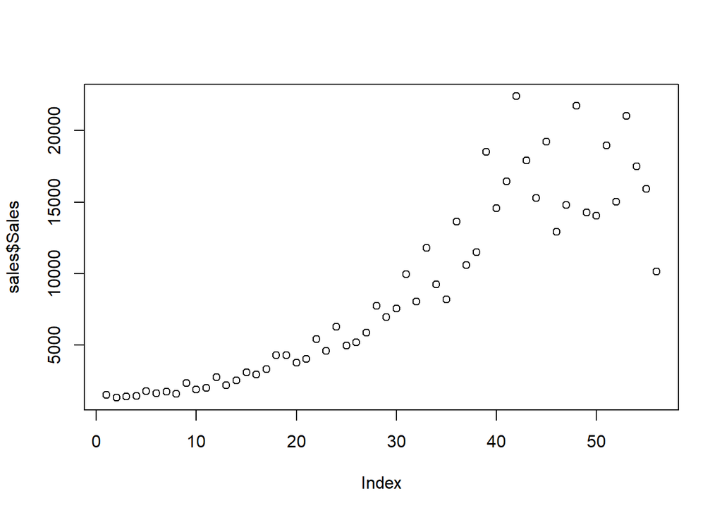

```r
sales = read.csv(file.choose())
plot(sales$Sales)
```

##Summary of Import Data -The first step before forecasting is to import the data. We can observe below that the data needs to be converted to times series in order to compare the different forecast methods.

#Plot and Inference #Show a time series plot.

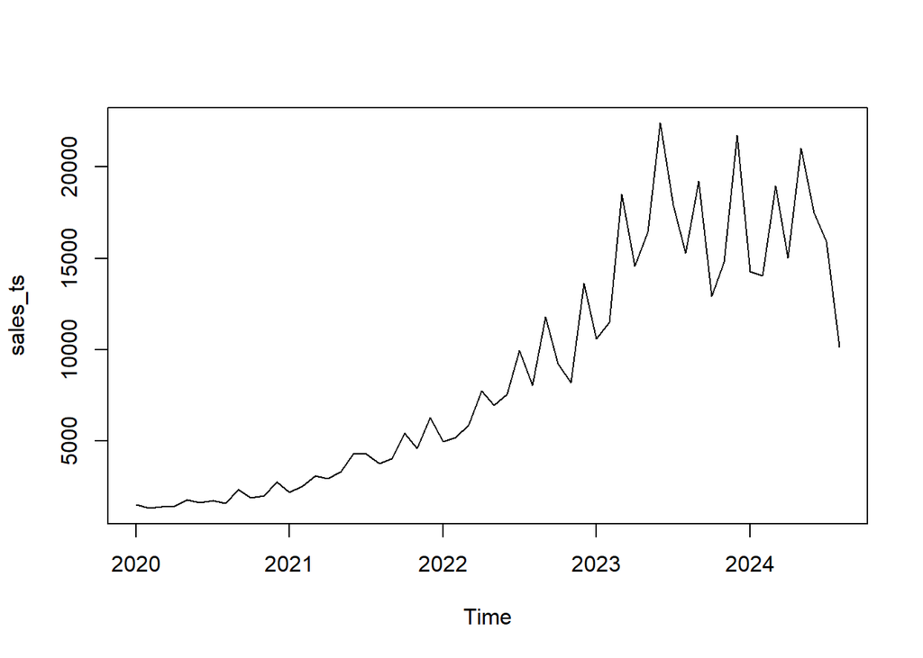

```r
sales_data = sales$Sales
sales_ts = ts(sales_data, frequency = 12, start = c(2020, 1))
plot(sales_ts)
```

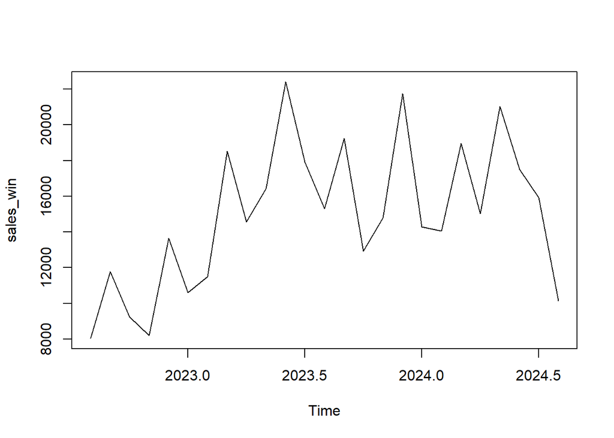

```r
sales_win = window(sales_ts, frequency = 12, start = c(2022, 8))
plot(sales_win)
```

#Central Tendency #What are the min, max, mean, median, 1st, and 3rd Quartile values of the times series?

```r
summary(sales_ts)
```

```
##    Min. 1st Qu.  Median    Mean 3rd Qu.    Max.
##    1322    2892    7246    8753   14346   22397
```

#Show the box plot.

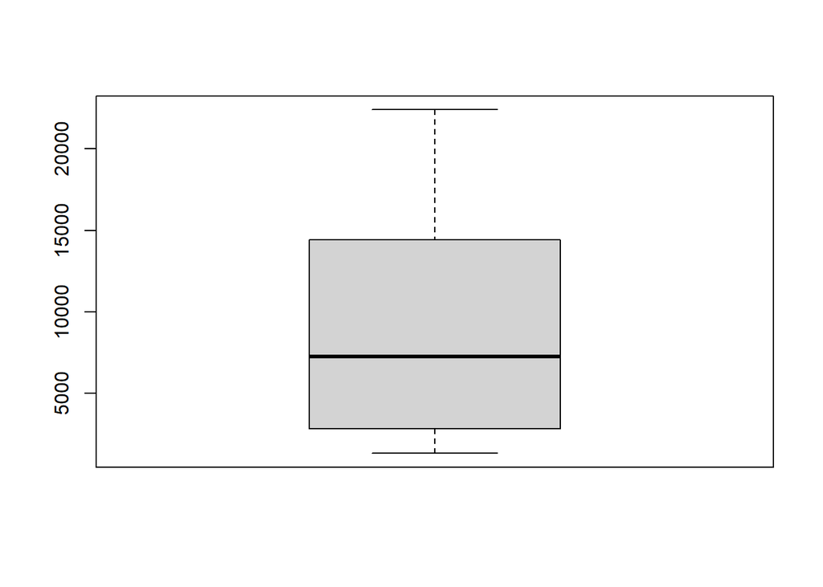

```r
boxplot(sales_ts)
```

#Can you summarize your observation about the time series from the summary stats and box plot? -In the summary results we can observe that the median is lower than the mean, indicating the distribution is right skewed. After plotting the box plot, we can observe there are no outliers in the data. Also we can confirm with the box plot that the data is right skewed.

#Decomposition #Plot the decomposition of the time series.

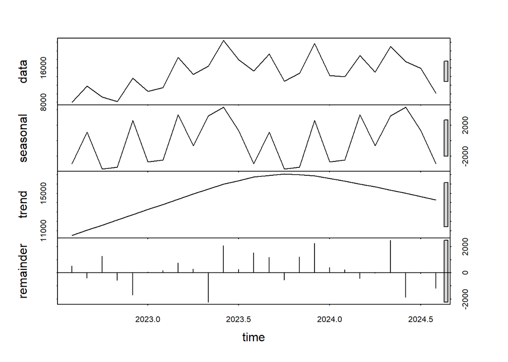

```r
stl_decom = stl(sales_win,s.window = "periodic")
plot(stl_decom)
```

#Is the time series seasonal?

```r
decomp = decompose(sales_win)
decomp
```

```
## $x
##            Jan       Feb       Mar       Apr       May       Jun       Jul
## 2022
## 2023 10595.275 11508.050 18523.723 14564.757 16429.514 22396.778 17920.701
## 2024 14272.846 14045.829 18958.669 15027.849 21039.214 17503.115 15919.392
##            Aug       Sep       Oct       Nov       Dec
## 2022  8044.484 11791.138  9245.218  8209.193 13634.657
## 2023 15296.844 19240.256 12924.107 14791.660 21750.222
## 2024 10151.933
##
## $seasonal
##             Jan        Feb        Mar        Apr        May        Jun
## 2022
## 2023 -3113.8485 -2990.8347  3464.5488  -958.0836   479.1159  5833.9619
## 2024 -3113.8485 -2990.8347  3464.5488  -958.0836   479.1159  5833.9619
##             Jul        Aug        Sep        Oct        Nov        Dec
## 2022            -2016.3247  1803.2238 -4550.3439 -2894.1567  4076.2365
## 2023   866.5052 -2016.3247  1803.2238 -4550.3439 -2894.1567  4076.2365
## 2024   866.5052 -2016.3247
##
## $trend
##           Jan      Feb      Mar      Apr      May      Jun      Jul      Aug
## 2022                                                                      NA
## 2023       NA 13874.14 14486.70 14950.37 15377.92 15990.34 16481.72 16740.70
## 2024 16814.22 16516.46       NA       NA       NA       NA       NA       NA
##           Sep      Oct      Nov      Dec
## 2022       NA       NA       NA       NA
## 2023 16864.56 16901.98 17113.34 17101.51
## 2024
##
## $random
##           Jan      Feb      Mar      Apr      May      Jun      Jul      Aug
## 2022                                                                      NA
## 2023       NA 624.7455 572.4734 572.4734 572.4734 572.4734 572.4734 572.4734
## 2024 572.4734 520.2013       NA       NA       NA       NA       NA       NA
##           Sep      Oct      Nov      Dec
## 2022       NA       NA       NA       NA
## 2023 572.4734 572.4734 572.4734 572.4734
## 2024
##
## $figure
##  [1] -2016.3247  1803.2238 -4550.3439 -2894.1567  4076.2365 -3113.8485
##  [7] -2990.8347  3464.5488  -958.0836   479.1159  5833.9619   866.5052
##
## $type
## [1] "additive"
##
## attr(,"class")
## [1] "decomposed.ts"
```

#Is the decomposition additive or multiplicative? -The decomposition is additive. We can observe that the seasonal variation is constant over each year and month.

#If seasonal, what are the values of the seasonal monthly indices?

```r
decomp$figure
```

```
##  [1] -2016.3247  1803.2238 -4550.3439 -2894.1567  4076.2365 -3113.8485
##  [7] -2990.8347  3464.5488  -958.0836   479.1159  5833.9619   866.5052
```

#Show the plot for time series adjusted for seasonality. Overlay this with the line foractuals? Does seasonality have big fluctuations in the value of time series?

```r
seasadj(stl_decom)
```

```
##           Jan      Feb      Mar      Apr      May      Jun      Jul      Aug
## 2022                                                                11026.90
## 2023 13343.82 14010.50 15147.76 15219.54 13230.75 18066.95 16627.18 18279.26
## 2024 17021.39 16548.27 15582.71 15682.63 17840.45 13173.29 14625.87 13134.35
##           Sep      Oct      Nov      Dec
## 2022 10667.69 12881.98 11612.39 11028.04
## 2023 18116.80 16560.87 18194.85 19143.60
## 2024
```

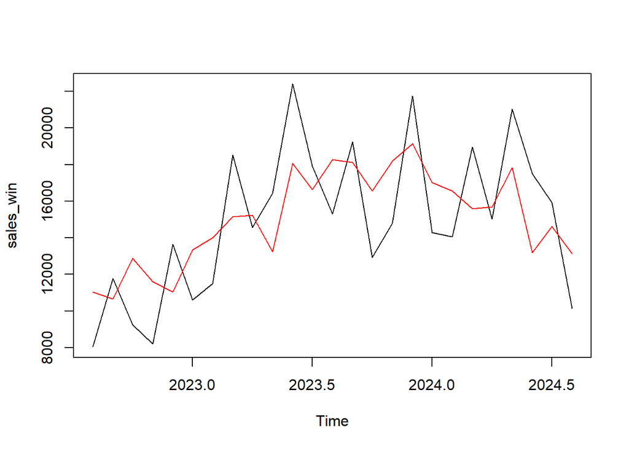

```r
plot(sales_win)
stl_decom = stl(sales_win,s.window = "periodic")
lines(seasadj(stl_decom), col="red")
```

-Yes the seasonality have big fluctuations over the value of the time series. For example, the last months of 2022 the value of the time series is dropping while the seasonality value is increasing.

#Naïve Method #Output

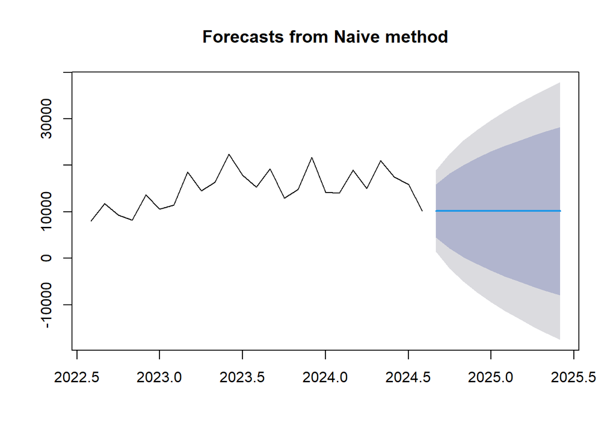

```r
naive_sales = naive(sales_win)
plot(naive_sales)
```

#Perform Residual Analysis for this technique. #Do a plot of residuals. What does the plot indicate?

```r
attributes(naive_sales)
```

```
## $names
##  [1] "method"    "model"     "lambda"    "x"         "fitted"    "residuals"
##  [7] "series"    "mean"      "level"     "lower"     "upper"
##
## $class
## [1] "forecast"
```

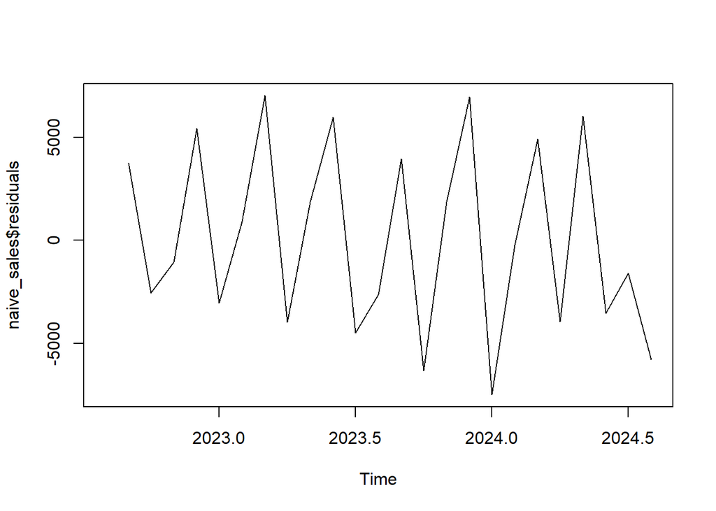

```r
plot(naive_sales$residuals)
```

-After plotting the residuals of the naive forecast we can observe that there is some seasonality pattern. Ideally, the residual plot should not have any pattern.

#Do a Histogram plot of residuals. What does the plot indicate?

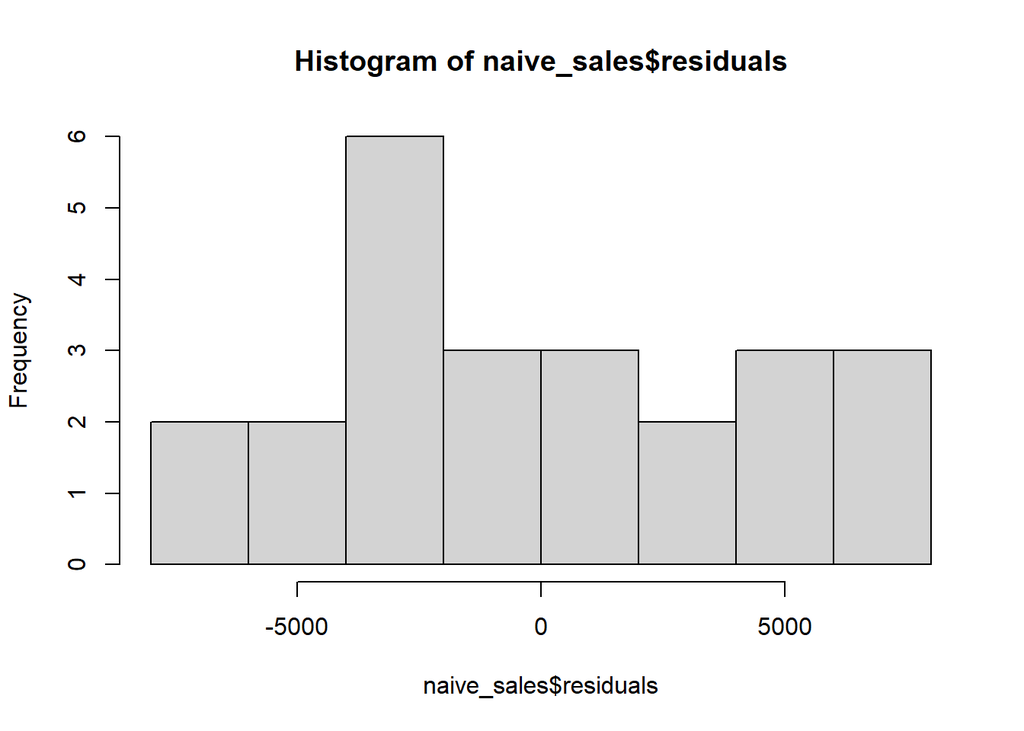

```r
hist(naive_sales$residuals)
```

-After plotting the residuals of the naive forecast, the histogram its not normally distributed. Ideally most of the values should be at zero

#Do a plot of fitted values vs. residuals. What does the plot indicate?

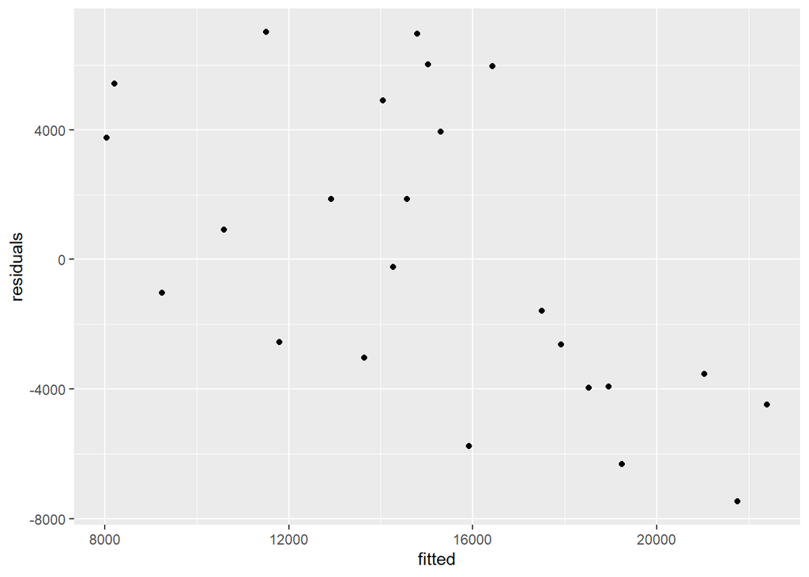

```r
library(ggplot2)
plot_naive = data.frame(fitted=naive_sales$fitted, residuals=naive_sales$residuals, actual=sales_win)
ggplot(plot_naive, aes(x=fitted, y=residuals))+geom_point()
```

-Ideally the scatter plot between the fitted and residuals should not have any pattern. The fitted values should have zero effect on the residual values. However this plot shows that the fitted values have effect on the residual value, the lower the fitted value is the higher the residual value is.

#Do a plot of actual values vs. residuals. What does the plot indicate?

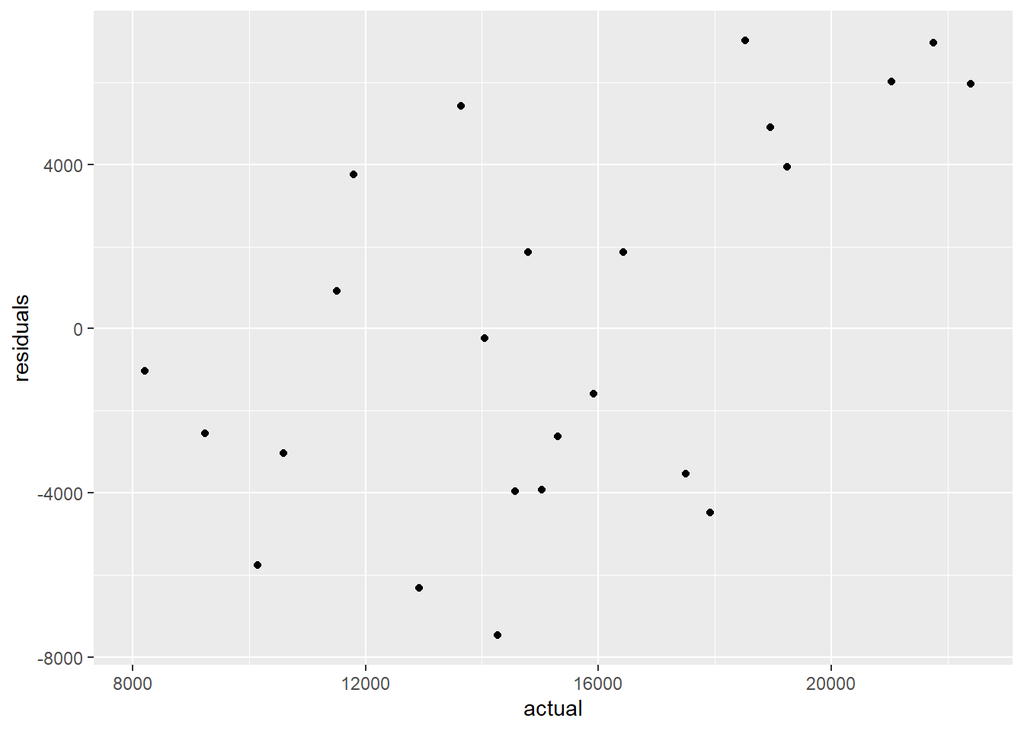

```r
ggplot(plot_naive, aes(x=actual, y=residuals))+geom_point()
```

-Similar to the previous plot, it shows that the actual values have effect on the residual values. Ideally the scatter plot should not have any pattern

#Do an ACF plot of the residuals? What does this plot indicate?

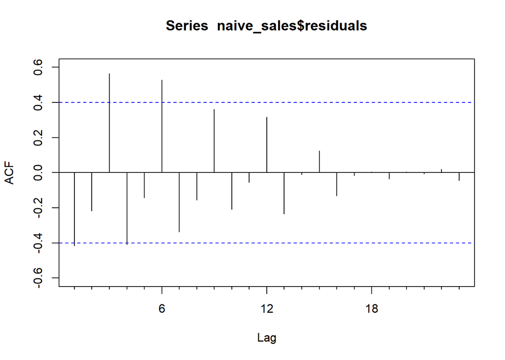

```r
Acf(naive_sales$residuals)
```

-In the Acf plot we can observe that some values have cross the confidence level showing trend data was missed in the naive forecast. Also the values that have not cross the confidence interval show seasonality in the data and were not included in the forecast.

#Print the five measures of accuracy for this forecasting technique

```r
naive_accuracy = accuracy(naive_sales)
naive_accuracy
```

```
##                    ME     RMSE      MAE       MPE     MAPE      MASE       ACF1
## Training set 87.81038 4468.937 3964.383 -3.299403 26.21323 0.9066808 -0.4168309
```

#Forecast #Time series value for next year. Show table and plot

```r
forecast_naive = forecast(naive_sales,12)
forecast_naive
```

[output not shown]

#Summarize this forecasting technique #How good is the accuracy? -I have chosen the RMSE accuracy measure to compare all the models. After doing the naive forecast, the accuracy result was high (4468.937), indicating that this might not be the right model to use.

#What does it predict the time series value will be in one year? 10151.93

#Simple Moving Averages #Plot the graph for the time series. #Show the Simple Moving average of order three on the plot above in Red #Show the Simple Moving average of order six on the plot above in Blue #Show the Simple Moving average of order nine on the plot above in Green

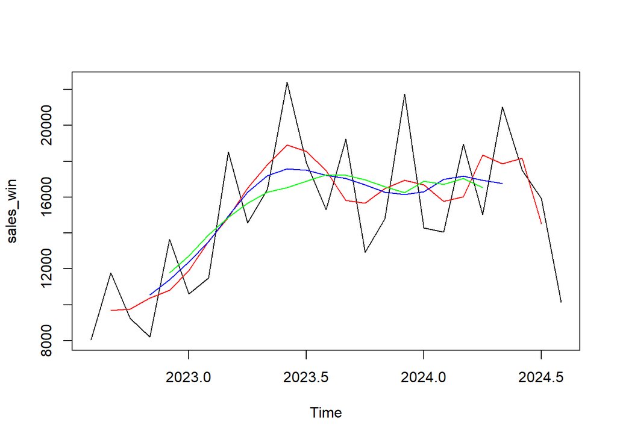

```r
mae3_sales = ma(sales_win,order = 3)
mae6_sales = ma(sales_win,order = 6)
mae9_sales = ma(sales_win,order = 9)
plot(sales_win)
lines(mae3_sales,col="red")
lines(mae6_sales,col="blue")
lines(mae9_sales,col="green")
```

#(Bonus) show the forecast for the next 12 months using one of the simple average orders that you feel works best for time series

```r
forecast_mae3 = forecast(mae3_sales, h=12)
```

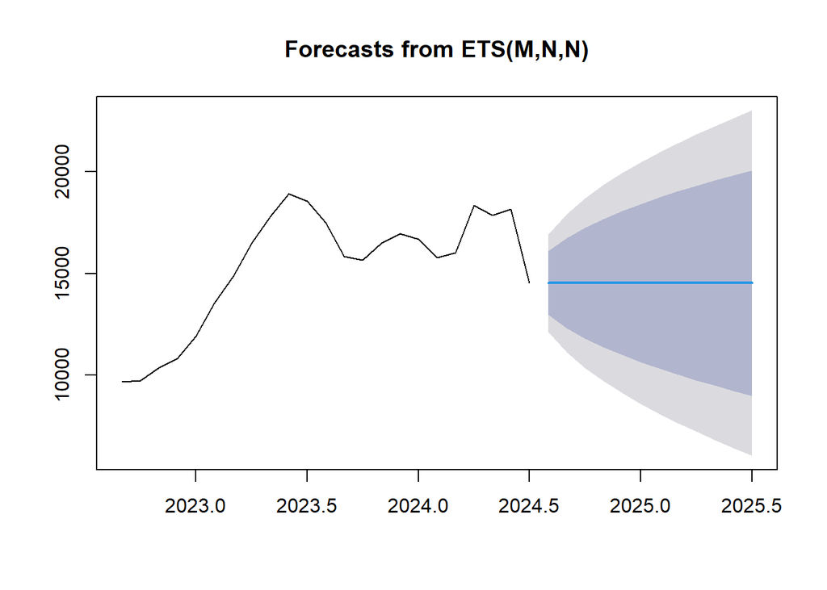

```r
plot(forecast_mae3)
```

#What are your observations of the plot as the moving average order goes up? -After plotting the three different moving averages, we can observe that higher the order number the more smooth the lines its. The lower the moving average the closer it is to the actual values.

#Simple Smoothing #Perform a simple smoothing forecast for the next 12 months for the time series.

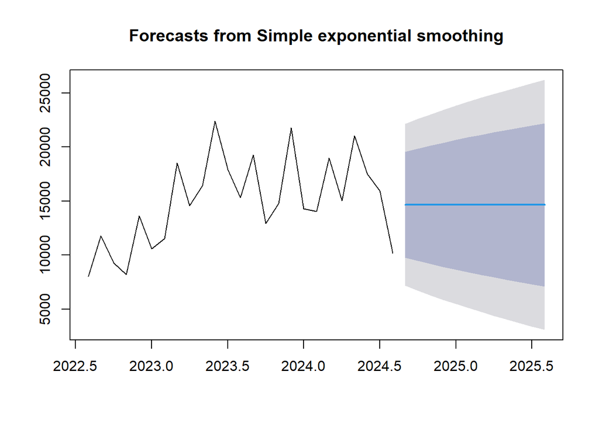

```r
ses_sales = ses(sales_win, 12)
plot(ses_sales)
```

#What is the value of alpha? What does that value signify?

```r
summary(ses_sales)
```

```
##
## Forecast method: Simple exponential smoothing
##
## Model Information:
## Simple exponential smoothing
##
## Call:
## ses(y = sales_win, h = 12)
##
##   Smoothing parameters:
##     alpha = 0.3549
##
##   Initial states:
##     l = 10062.2044
##
##   sigma:  3817.847
##
##      AIC     AICc      BIC
## 496.7594 497.9023 500.4161
##
## Error measures:
##                  ME    RMSE      MAE        MPE     MAPE     MASE       ACF1
## Training set 515.98 3661.95 2930.488 -0.6728972 19.71913 0.670222 -0.1030086
##
## Forecasts:
##          Point Forecast    Lo 80    Hi 80    Lo 95    Hi 95
## Sep 2024       14640.16 9747.388 19532.92 7157.313 22123.00
## Oct 2024       14640.16 9448.402 19831.91 6700.054 22580.26
## Nov 2024       14640.16 9165.721 20114.59 6267.731 23012.58
## Dec 2024       14640.16 8896.937 20383.37 5856.661 23423.65
## Jan 2025       14640.16 8640.182 20640.13 5463.987 23816.32
## Feb 2025       14640.16 8393.972 20886.34 5087.441 24192.87
## Mar 2025       14640.16 8157.105 21123.21 4725.186 24555.13
## Apr 2025       14640.16 7928.593 21351.72 4375.707 24904.60
## May 2025       14640.16 7707.609 21572.70 4037.741 25242.57
## Jun 2025       14640.16 7493.455 21786.86 3710.221 25570.09
## Jul 2025       14640.16 7285.534 21994.78 3392.233 25888.08
## Aug 2025       14640.16 7083.332 22196.98 3082.991 26197.32
```

The value of alpha is 0.3549. The alpha value is not close to 1, giving more weight to more past values and less responsive to changes.

#What is the value of the initial state? -10062.2044

#What is the value of sigma? What does the sigma signify? -The value of sigma is 3817.847 The higher the value of sigma the more variability and the less reliable the forecast it is.

#Perform Residual Analysis for this technique. #Do a plot of residuals. What does the plot indicate?

```r
attributes(ses_sales)
```

```
## $names
##  [1] "model"     "mean"      "level"     "x"         "upper"     "lower"
##  [7] "fitted"    "method"    "series"    "residuals"
##
## $class
## [1] "forecast"
```

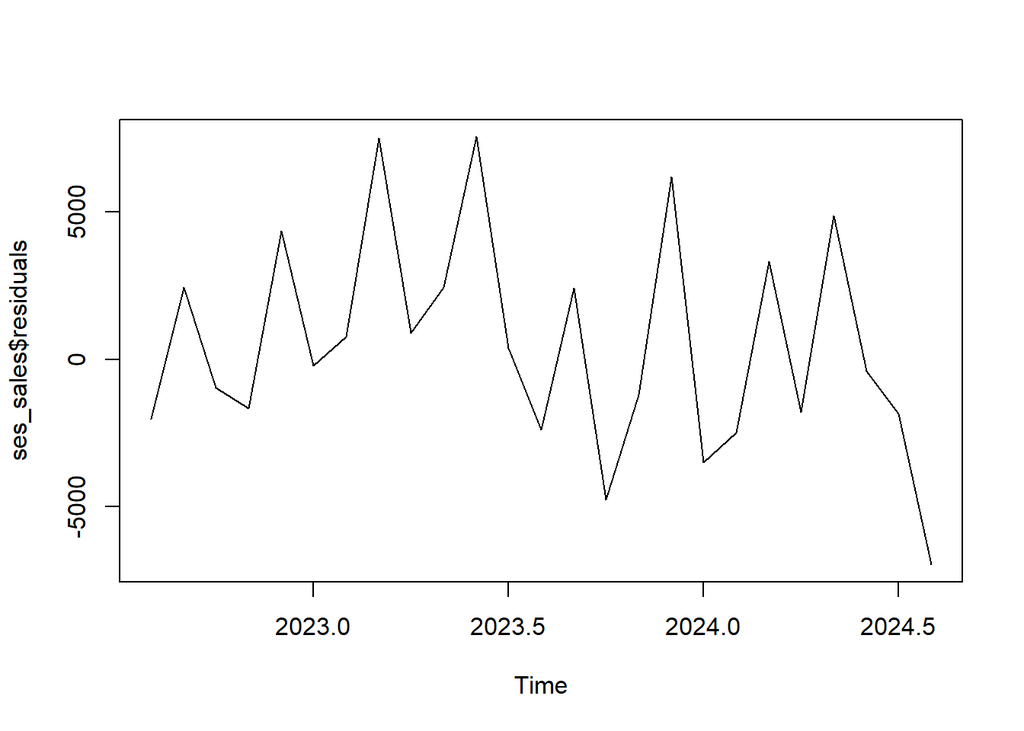

```r
plot(ses_sales$residuals)
```

-After plotting the residuals of the simple exponential smoothing we can observe that there is some seasonality pattern. Ideally, the residual plot should not have any pattern.

#Do a Histogram plot of residuals. What does the plot indicate?

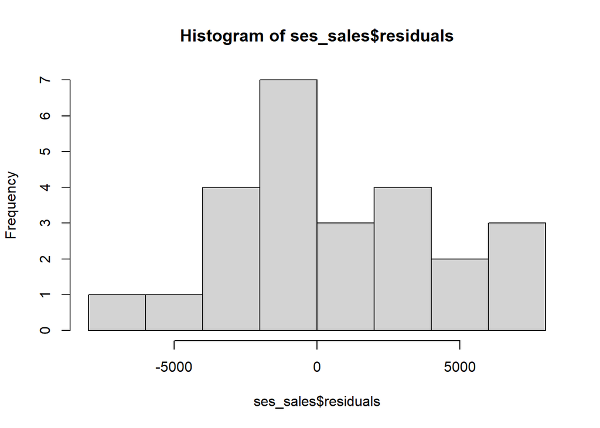

```r
hist(ses_sales$residuals)
```

-After plotting the residuals of the simple exponential smoothing, the histogram its not normally distributed. Ideally most of the values should be at zero.

#Do a plot of fitted values vs. residuals. What does the plot indicate?

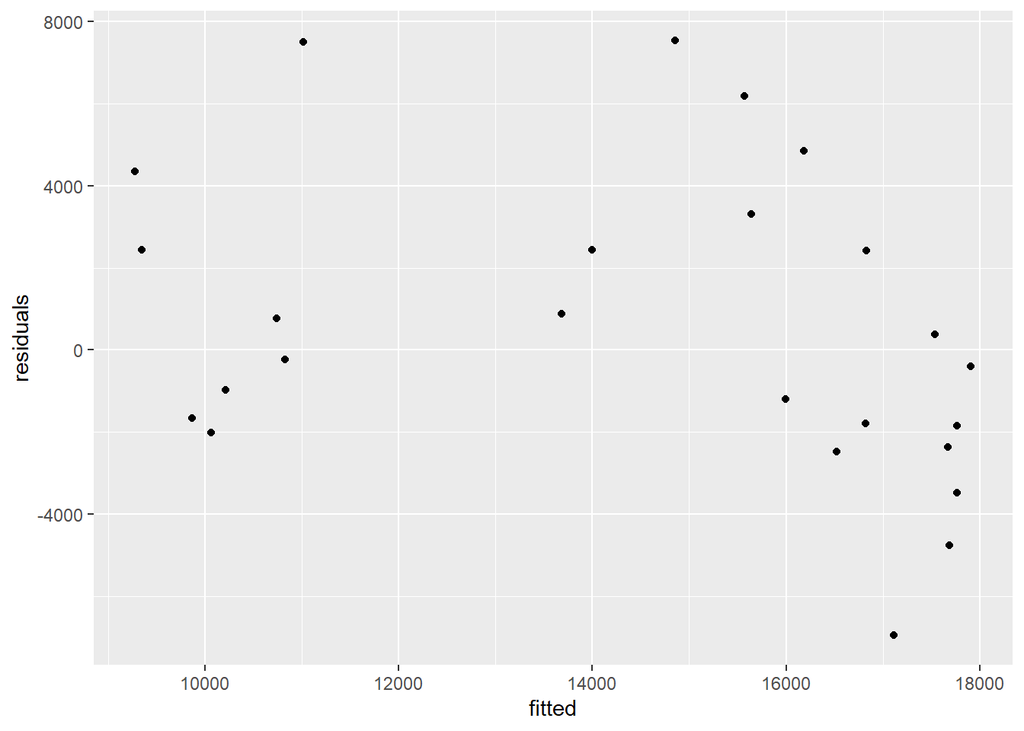

```r
plot_ses = data.frame(fitted=ses_sales$fitted, residuals=ses_sales$residuals, actual=sales_win)
ggplot(plot_ses, aes(x=fitted, y=residuals))+geom_point()
```

-Ideally the scatter plot between the fitted and residuals should not have any pattern. The fitted values should have zero effect on the residual values. However this plot shows that the fitted values have effect on the residual values.

#Do a plot of actual values vs. residuals. What does the plot indicate?

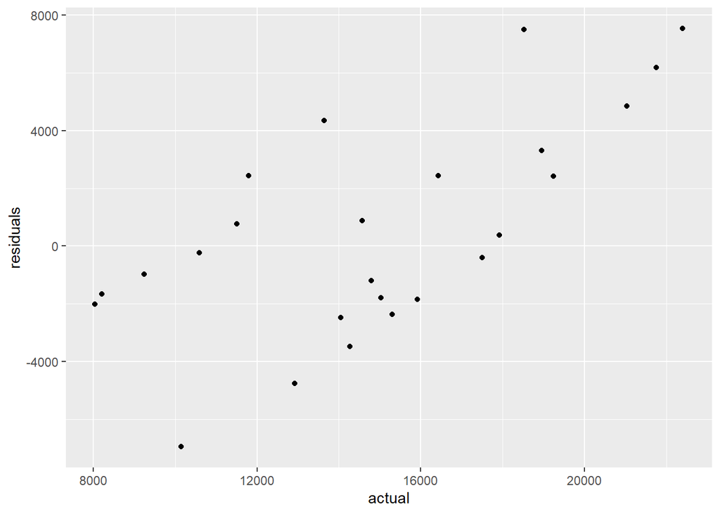

```r
ggplot(plot_ses, aes(x=actual, y=residuals))+geom_point()
```

-Similar to the previous plot, it shows that the actual values have effect on the residual values. Ideally the scatter plot should not have any pattern.

#Do an ACF plot of the residuals? What does this plot indicate?

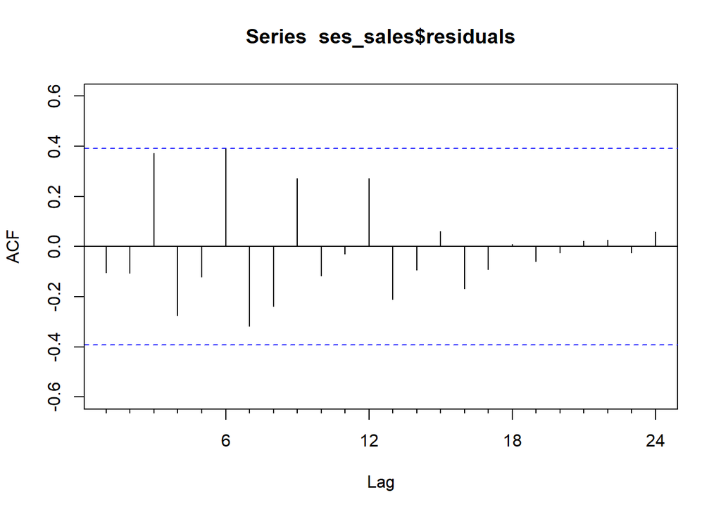

```r
Acf(ses_sales$residuals)
```

-In the Acf plot we can observe that some values are on the confidence interval showing trend data was not included in the forecast. Also the values that have not cross the confidence interval show seasonality in the data and was not included in the forecast.

#Print the five measures of accuracy for this forecasting technique

```r
ses_accuracy = accuracy(ses_sales)
ses_accuracy
```

```
##                  ME    RMSE      MAE        MPE     MAPE     MASE       ACF1
## Training set 515.98 3661.95 2930.488 -0.6728972 19.71913 0.670222 -0.1030086
```

#Forecast #Time series value for next year. Show table and plot

```r
forecast_ses = forecast(ses_sales, h=12)
forecast_ses
```

```
##          Point Forecast    Lo 80    Hi 80    Lo 95    Hi 95
## Sep 2024       14640.16 9747.388 19532.92 7157.313 22123.00
## Oct 2024       14640.16 9448.402 19831.91 6700.054 22580.26
## Nov 2024       14640.16 9165.721 20114.59 6267.731 23012.58
## Dec 2024       14640.16 8896.937 20383.37 5856.661 23423.65
## Jan 2025       14640.16 8640.182 20640.13 5463.987 23816.32
## Feb 2025       14640.16 8393.972 20886.34 5087.441 24192.87
## Mar 2025       14640.16 8157.105 21123.21 4725.186 24555.13
## Apr 2025       14640.16 7928.593 21351.72 4375.707 24904.60
## May 2025       14640.16 7707.609 21572.70 4037.741 25242.57
## Jun 2025       14640.16 7493.455 21786.86 3710.221 25570.09
## Jul 2025       14640.16 7285.534 21994.78 3392.233 25888.08
## Aug 2025       14640.16 7083.332 22196.98 3082.991 26197.32
```

#Summarize this forecasting technique #How good is the accuracy? -I have chosen the RMSE accuracy measure to compare all the models. After doing the simple exponential smoothing forecast, the accuracy result was high (3661.95), indicating that this might not be the right model to use. However, the accuracy result is better than the naive.

#What does it predict the time series value will be in one year? -14640.16

#Holt-Winters #Perform Holt-Winters forecast for the next 12 months for the time series.

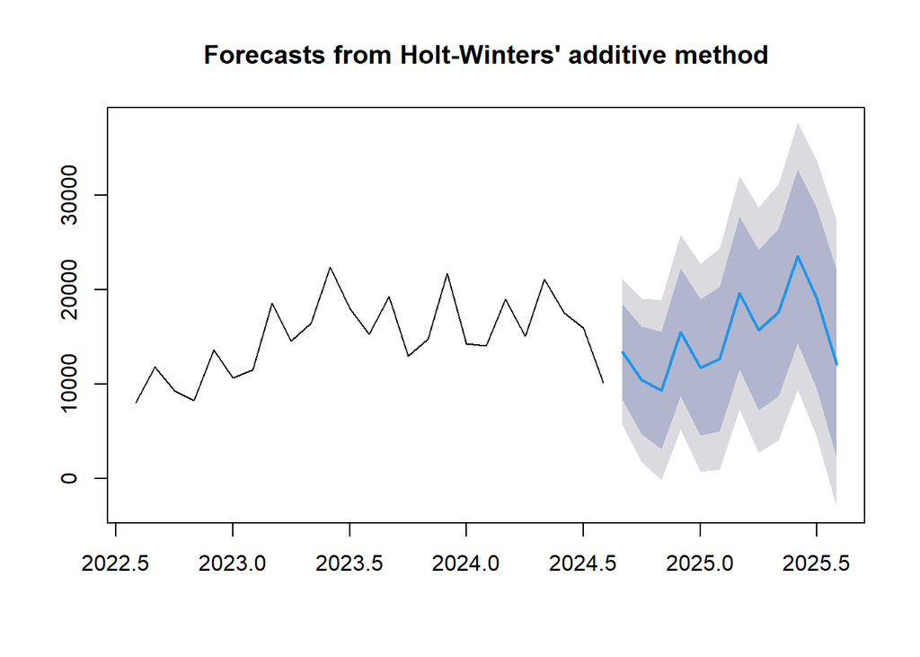

```r
hw_sales = hw(sales_win, h=12)
plot(hw_sales)
```

#What is the value of alpha? What does that value signify?

```r
summary(hw_sales)
```

```
##
## Forecast method: Holt-Winters' additive method
##
## Model Information:
## Holt-Winters' additive method
##
## Call:
## hw(y = sales_win, h = 12)
##
##   Smoothing parameters:
##     alpha = 0.5086
##     beta  = 1e-04
##     gamma = 1e-04
##
##   Initial states:
##     l = 12519.877
##     b = 191.1975
##     s = 3141.449 7809.477 2034.435 361.7775 4512.03 -2312.437
##            -3033.341 934.5735 -5035.702 -3807.886 -602.2986 -4002.076
##
##   sigma:  3943.054
##
##      AIC     AICc      BIC
## 502.9162 590.3447 523.6370
##
## Error measures:
##                     ME     RMSE      MAE       MPE     MAPE      MASE
## Training set -275.0497 2365.832 1545.337 -1.995922 9.849879 0.3534289
##                     ACF1
## Training set -0.04168513
##
## Forecasts:
##          Point Forecast     Lo 80    Hi 80      Lo 95    Hi 95
## Sep 2024      13392.975  8339.748 18446.20  5664.7312 21121.22
## Oct 2024      10377.464  4708.005 16046.92  1706.7744 19048.15
## Nov 2024       9340.533  3115.334 15565.73  -180.0869 18861.15
## Dec 2024      15501.198  8765.763 22236.63  5200.2385 25802.16
## Jan 2025      11723.412  4513.576 18933.25   696.9187 22749.91
## Feb 2025      12634.819  4979.751 20289.89   927.4033 24342.24
## Mar 2025      19649.685 11573.730 27725.64  7298.5776 32000.79
## Apr 2025      15690.100  7213.975 24166.22  2726.9854 28653.21
## May 2025      17553.763  8695.377 26412.15  4006.0308 31101.50
## Jun 2025      23518.134 14293.169 32743.10  9409.7674 37626.50
## Jul 2025      19041.313  9463.650 28618.98  4393.5419 33689.08
## Aug 2025      12088.835  2170.875 22006.79 -3079.3761 27257.05
```

-The value of alpha is 0.5086. The alpha value closer to 1 will give more weight to more past values and less responsive to changes. In this case alpha is somewhere in the middle.

#What is the value of gamma? What does that value signify? -The value of gamma is 0.0001. The gamma values control the weight of the seasonal component, higher values gives weights to the more recent observations of the seasonality. In this case gamma is very low.

#What is the value of initial states for the level, trend, and seasonality? What do these values signify? -Initial states: l = 12519.877 b = 191.1975 s = 3141.449 7809.477 2034.435 361.7775 4512.03 -2312.437 -3033.341 934.5735 -5035.702 -3807.886 -602.2986 -4002.076

#What is the value of sigma? What does the sigma signify? -The value of sigma is 3943.054. The higher the value of sigma the more variability and the less reliable the forecast it is.

#Perform Residual Analysis for this technique. #Do a plot of residuals. What does the plot indicate?

```r
attributes(hw_sales)
```

```
## $names
##  [1] "model"     "mean"      "level"     "x"         "upper"     "lower"
##  [7] "fitted"    "method"    "series"    "residuals"
##
## $class
## [1] "forecast"
```

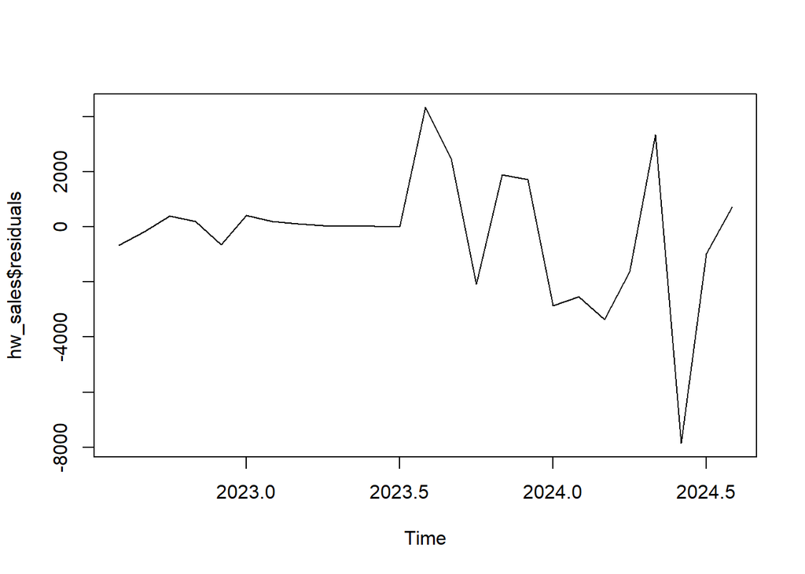

```r
plot(hw_sales$residuals)
```

-The residuals appear to be random.

#Do a Histogram plot of residuals. What does the plot indicate?

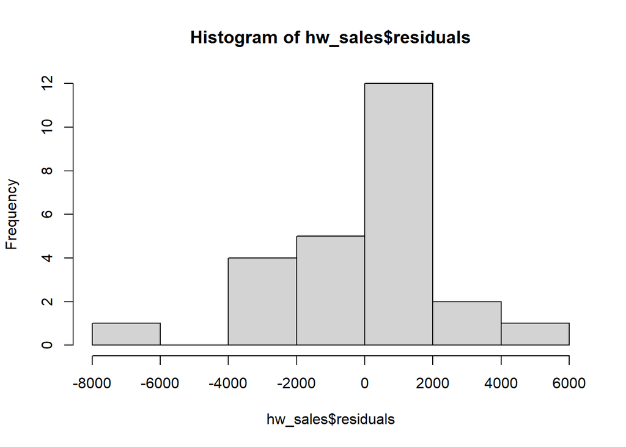

```r
hist(hw_sales$residuals)
```

-After plotting the residuals of the holtwinters, the histogram it is normally distributed, most of the values have a mean of zero.

#Do a plot of fitted values vs. residuals. What does the plot indicate?

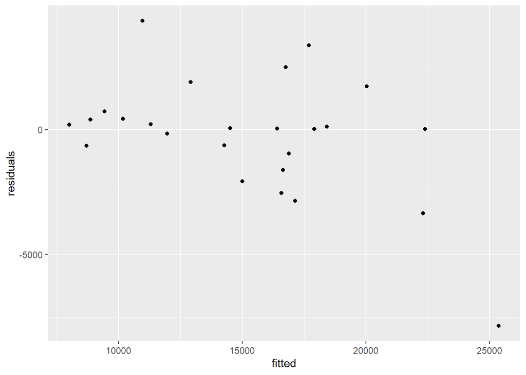

```r
plot_hw = data.frame(fitted=hw_sales$fitted, residuals=hw_sales$residuals, actual=sales_win)
ggplot(plot_hw, aes(x=fitted, y=residuals))+geom_point()
```

-In this graph we can observed that the fitted values have no effect on the residual values. If we were to add a straight line in the zero, all the values move in the same direction.

#Do a plot of actual values vs. residuals. What does the plot indicate?

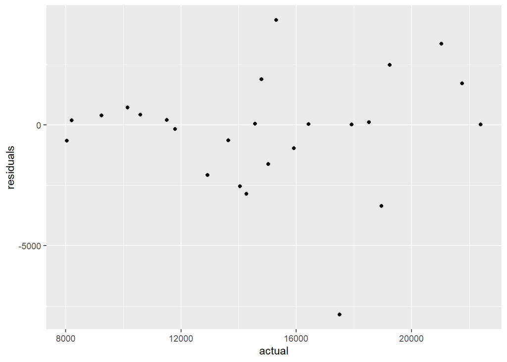

```r
ggplot(plot_hw, aes(x=actual, y=residuals))+geom_point()
```

-Similar to the previous plot, it seems that the actual values have no effect on the residual values.

#Do an ACF plot of the residuals? What does this plot indicate?

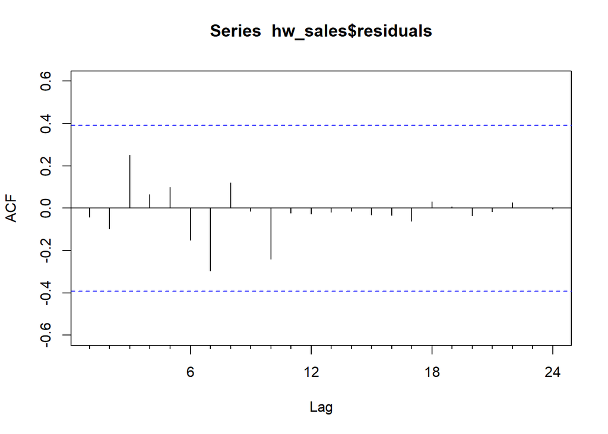

```r
Acf(hw_sales$residuals)
```

-We can observe that all the values in the Acf plot of the Holt- Winters have not cross the confidence interval. Meaning that this is a good forecast comparing to the previous ones.

#Print the five measures of accuracy for this forecasting technique

```r
hw_accuracy = accuracy(hw_sales)
hw_accuracy
```

```
##                     ME     RMSE      MAE       MPE     MAPE      MASE
## Training set -275.0497 2365.832 1545.337 -1.995922 9.849879 0.3534289
##                     ACF1
## Training set -0.04168513
```

#Forecast #Time series value for next year. Show table and plot

```r
forecast_hw = forecast(hw_sales, h=12)
forecast_hw
```

```
##          Point Forecast     Lo 80    Hi 80      Lo 95    Hi 95
## Sep 2024      13392.975  8339.748 18446.20  5664.7312 21121.22
## Oct 2024      10377.464  4708.005 16046.92  1706.7744 19048.15
## Nov 2024       9340.533  3115.334 15565.73  -180.0869 18861.15
## Dec 2024      15501.198  8765.763 22236.63  5200.2385 25802.16
## Jan 2025      11723.412  4513.576 18933.25   696.9187 22749.91
## Feb 2025      12634.819  4979.751 20289.89   927.4033 24342.24
## Mar 2025      19649.685 11573.730 27725.64  7298.5776 32000.79
## Apr 2025      15690.100  7213.975 24166.22  2726.9854 28653.21
## May 2025      17553.763  8695.377 26412.15  4006.0308 31101.50
## Jun 2025      23518.134 14293.169 32743.10  9409.7674 37626.50
## Jul 2025      19041.313  9463.650 28618.98  4393.5419 33689.08
## Aug 2025      12088.835  2170.875 22006.79 -3079.3761 27257.05
```

#Summarize this forecasting technique #How good is the accuracy? -I have chosen the RMSE accuracy measure to compare all the models. After doing the holt winters forecast, the accuracy result is 2365.832. Comparing to all the forecast methods, holtwinters have the lowers RMSE accuracy.

#What does it predict the time series value will be in one year? Point Forecast Sep 2024 13392.975  
Oct 2024 10377.464  
Nov 2024 9340.533  
Dec 2024 15501.198  
Jan 2025 11723.412  
Feb 2025 12634.819  
Mar 2025 19649.685  
Apr 2025 15690.100  
May 2025 17553.763  
Jun 2025 23518.134

#Accuracy Summary #Show a table of all the forecast methods above with their accuracy measures.

```r
table_accuracy=data.frame(Method=c("Naive","Exponential Smoothing","Holt-Winters"), ME=c(naive_accuracy[1,"ME"],ses_accuracy[1,"ME"], hw_accuracy[1,"ME"]), RMSE=c(naive_accuracy[1,"RMSE"], ses_accuracy[1,"RMSE"], hw_accuracy[1,"RMSE"]), MAE=c(naive_accuracy[1,"MAE"], ses_accuracy[1,"MAE"], hw_accuracy[1,"MAE"]), MAPE=c(naive_accuracy[1,"MAPE"], ses_accuracy[1,"MAPE"], hw_accuracy[1,"MAPE"]), MASE=c(naive_accuracy[1,"MASE"], ses_accuracy[1,"MASE"], hw_accuracy[1,"MASE"]))
print(table_accuracy)
```

```
##                  Method         ME     RMSE      MAE      MAPE      MASE
## 1                 Naive   87.81038 4468.937 3964.383 26.213234 0.9066808
## 2 Exponential Smoothing  515.97998 3661.950 2930.488 19.719130 0.6702220
## 3          Holt-Winters -275.04965 2365.832 1545.337  9.849879 0.3534289
```

#Separately define each forecast method and why it is useful. Show the best and worst forecast method for each of the accuracy measures. -Based on the RMSE accuracy, Holwintwers has the lowest accuracy error and naive has the highest score. I have chosen the RMSE accuracy because it gives higher weight to larger errors. Naive: -The naive method will take the previous data to forecast the next value. Therefore, naive is very simple to forecast and could be the baseline to compare to other methods. Exponential Smoothing: -The exponential smoothing can give more weight to more recent data. It will also be beneficial when the analysis has trend data. Holt-Winters: -The Holt-Winter method could be apply when the data has level, trend and seasonality. Also, holt-winters can be use for additive and multiplicative forecasts.

#Conclusion #Summarize your analysis of time series value over the time period. -Based on the analysis perform the data seems to have both trend and seasonality. -After performing the forecast above, we can conclude Holt-Winters has the lowest accuracy errors. -Also, the values in the residual plot in the Holt-Winters are within the confidence interval.

#Based on your analysis and forecast above, do you think the value of the time series will increase, decrease, or stay flat over the next year? How about the next 2 years?

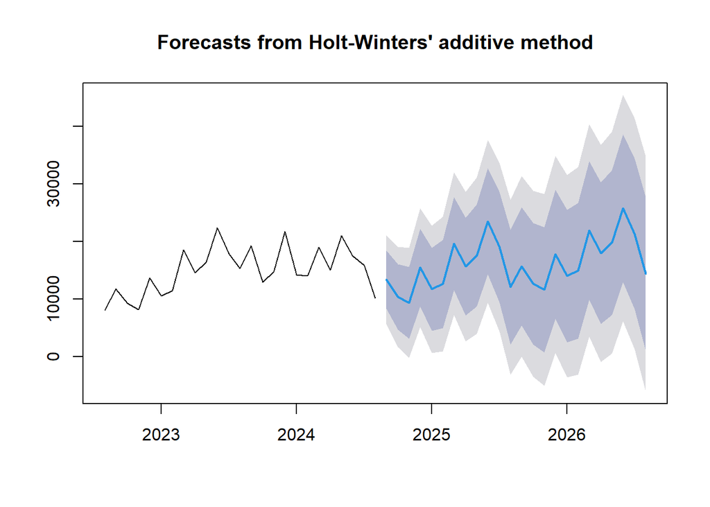

```r
hw_sales = hw(sales_win, h=24)
plot(hw_sales)
```

#Rank forecasting methods for this time series based on historical values.

```r
table_accuracy=data.frame(Method=c("Naive","Exponential Smoothing","Holt-Winters"), ME=c(naive_accuracy[1,"ME"],ses_accuracy[1,"ME"], hw_accuracy[1,"ME"]), RMSE=c(naive_accuracy[1,"RMSE"], ses_accuracy[1,"RMSE"], hw_accuracy[1,"RMSE"]), MAE=c(naive_accuracy[1,"MAE"], ses_accuracy[1,"MAE"], hw_accuracy[1,"MAE"]), MAPE=c(naive_accuracy[1,"MAPE"], ses_accuracy[1,"MAPE"], hw_accuracy[1,"MAPE"]), MASE=c(naive_accuracy[1,"MASE"], ses_accuracy[1,"MASE"], hw_accuracy[1,"MASE"]))
print(table_accuracy)
```

```
##                  Method         ME     RMSE      MAE      MAPE      MASE
## 1                 Naive   87.81038 4468.937 3964.383 26.213234 0.9066808
## 2 Exponential Smoothing  515.97998 3661.950 2930.488 19.719130 0.6702220
## 3          Holt-Winters -275.04965 2365.832 1545.337  9.849879 0.3534289
```